# Lecture 8 - Social Neuroscience: Understanding others

# Understanding others

For an overview, See Chapter 6 from Ward (2022)

## Overview

- Recap “Social Brain” circuits
- Background
- Cognitive and brain systems
  - Mirror neuron system
  - Theory of mind network

# Recap social brain circuits

## Social brain circuits

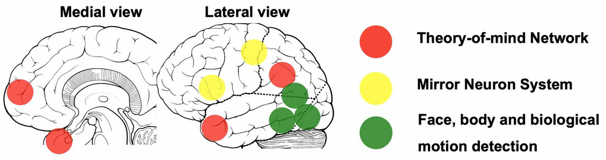

(Adolphs, 2009; Stanley & Adolphs, 2013)

# Background

## Mindreading?

[figure not shown]

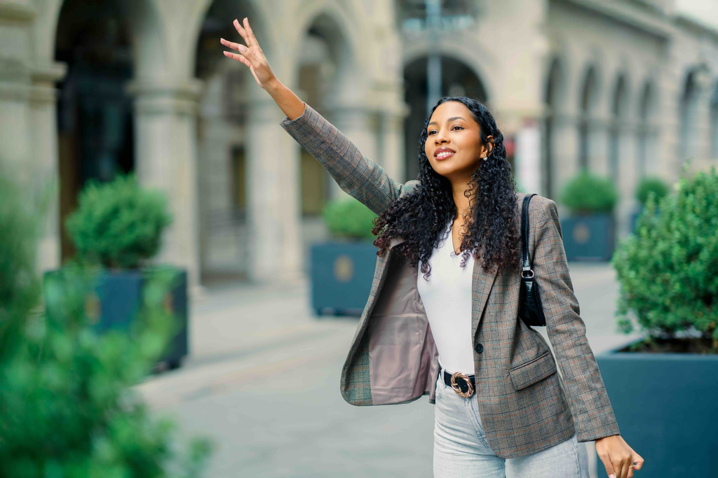

## Beliefs about beliefs

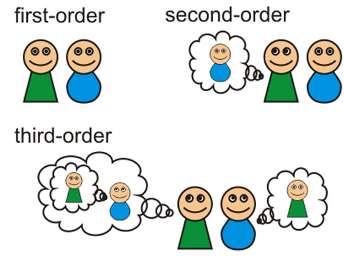

## Spontaneous

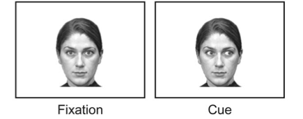

[figure not shown]

[figure not shown]

[figure not shown]

(Frischen et al., 2007)

## Why is it important?

[figure not shown]

prediction

## Why is it important?

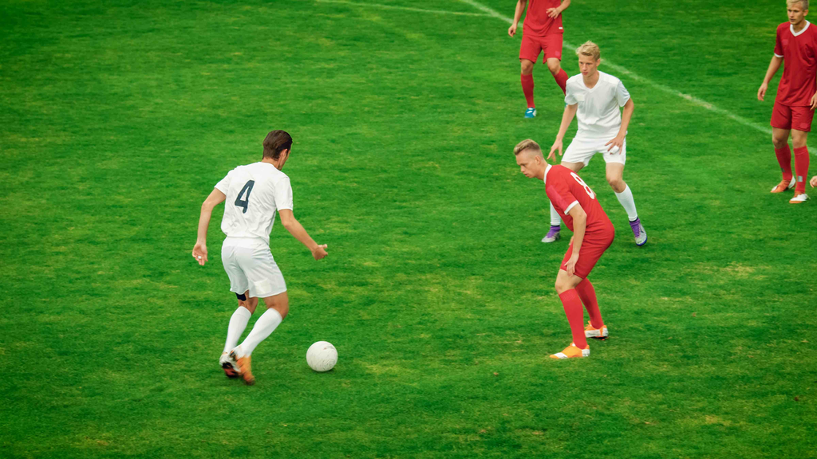

manipulation

## Why is it important?

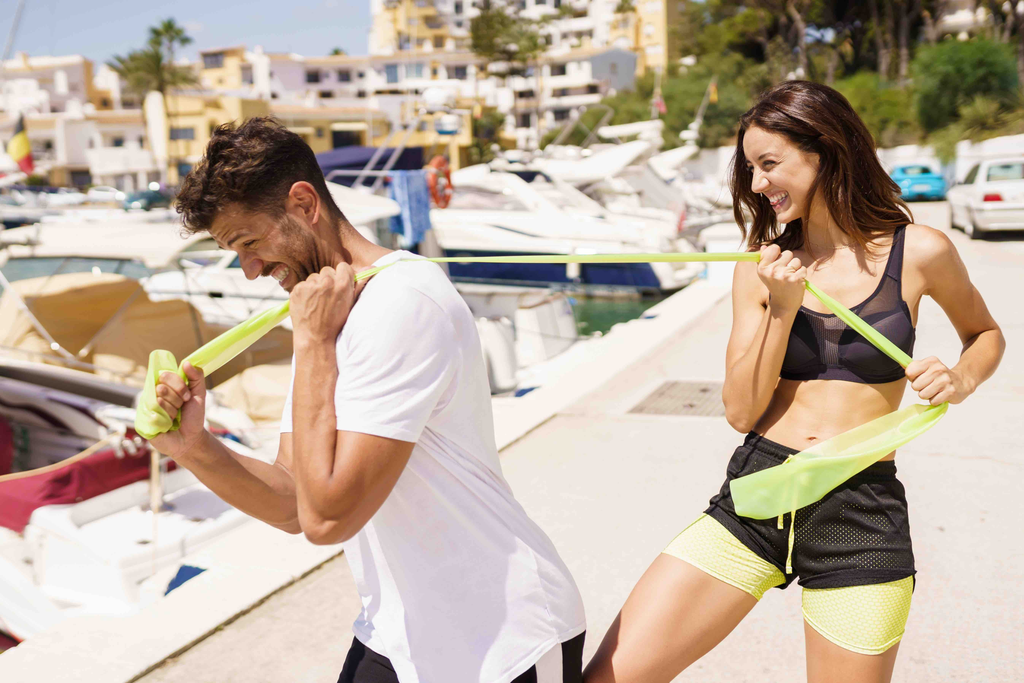

joint action

# Cognitive and brain systems

- Mirror neuron system
- Theory of mind network

## Mirror neurons

[video not shown]

## Mirror neurons in macaques

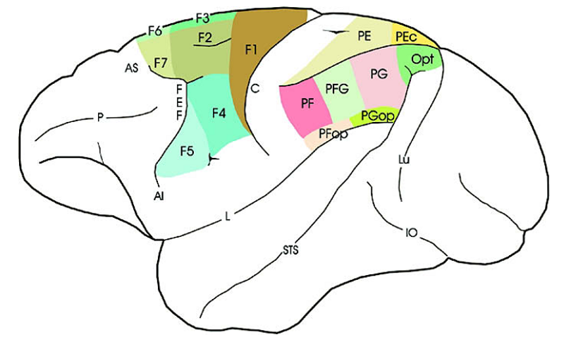

F5 and PF

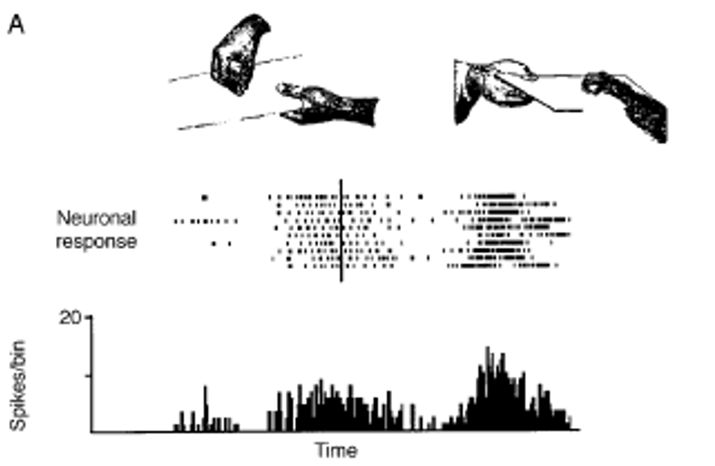

(di Pellegrino et al., 1992; Fogassi et al., 2005; Gallese et al., 1996)

## Mirror neuron system in humans

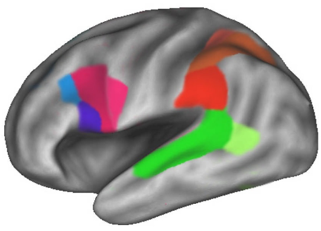

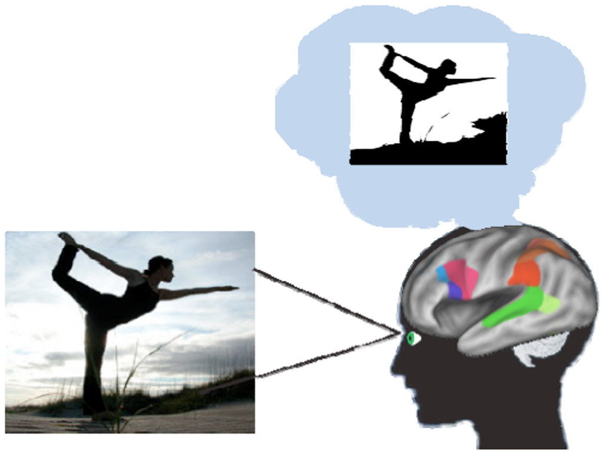

The direct matching hypothesis

(Gazzola & Keysers, 2009; Rizzolatti et al., 2001)

## Theory of mind

ToM = reasoning about mental states

[figure not shown]

Le Tricheur à l’as de carreau by Georges de la Tour (c. 1635)

## Theory of mind development

[video not shown]

## The false belief task

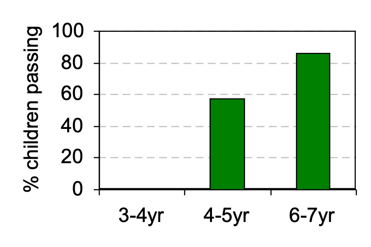

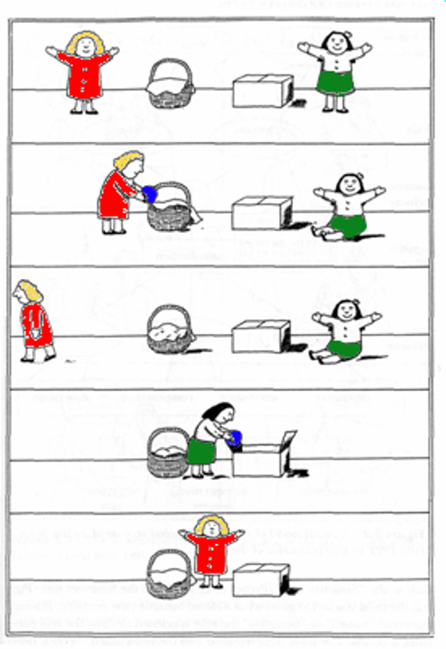

(Wimmer & Perner, 1983)

## Brain circuits

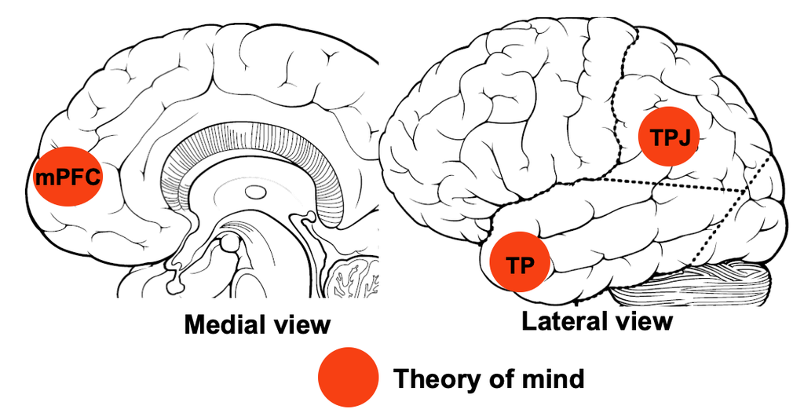

- mPFC: person knowledge
- TPJ: false belief, perspective taking
- TP: social scripts, emotion, convergence ?

(Schurz et al., 2014; Van Overwalle, 2009)

## Caution

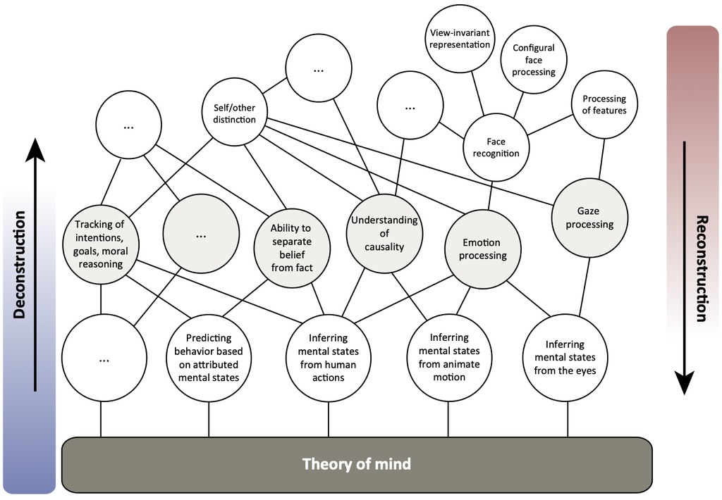

(Schaafsma et al., 2015)

## Mirroring and theory of mind

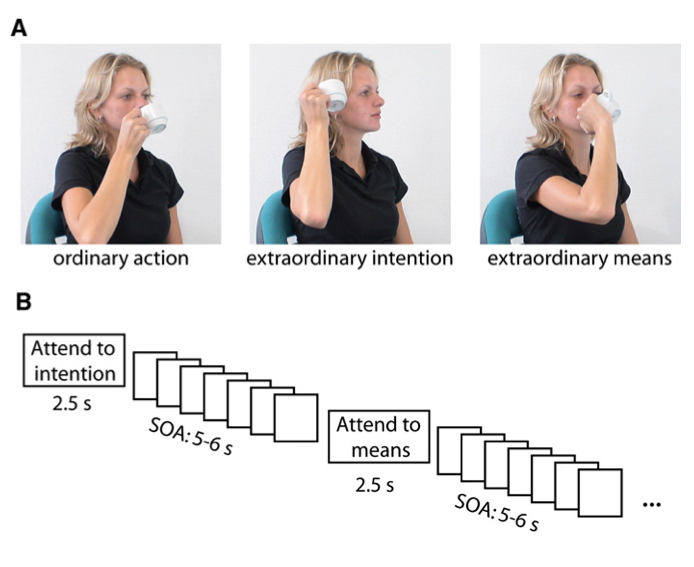

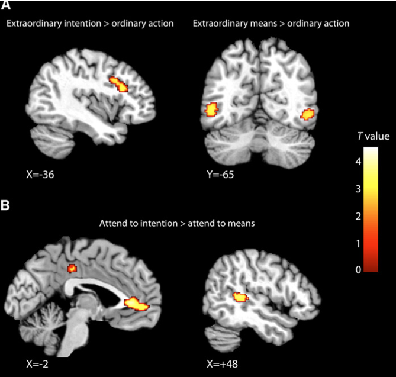

(de Lange et al., 2008)

## Mirroring and theory of mind

- Complementary roles in social cognition.
- How do they influence each other?
- Lots of open and unanswered questions.
- Essay questions?

(Keysers & Gazzola, 2007)

# Take a break

# Part 2 - Read and discuss

## Discussion material

- break into small groups (~ 5 per group)
- discuss aspects of the lecture
- discuss aspects of the journal article: https://www.sciencedirect.com/science/article/pii/S1364661314002502?via%3Dihub

## References

Adolphs, R. (2009). The Social Brain: Neural Basis of Social Knowledge. *Annual Review of Psychology*, *60*(1), 693–716. https://doi.org/10.1146/annurev.psych.60.110707.163514

de Lange, F. P., Spronk, M., Willems, R. M., Toni, I., & Bekkering, H. (2008). *Complementary Systems for Understanding Action Intentions*. *18*(6), 454–457. http://linkinghub.elsevier.com/retrieve/pii/S0960982208002443

di Pellegrino, G., Fadiga, L., Fogassi, L., Gallese, V., & Rizzolatti, G. (1992). Understanding motor events: A neurophysiological study. *Exp Brain Res*, *91*(1), 176–180. http://www.ncbi.nlm.nih.gov/htbin-post/Entrez/query?db=m&form=6&dopt=r&uid=1301372

Fogassi, L., Ferrari, P. F., Gesierich, B., Rozzi, S., Chersi, F., & Rizzolatti, G. (2005). Parietal lobe: From action organization to intention understanding. *Science*, *308*(5722), 662–667. http://www.ncbi.nlm.nih.gov/entrez/query.fcgi?cmd=Retrieve&db=PubMed&dopt=Citation&list_uids=15860620

Frischen, A., Bayliss, A. P., & Tipper, S. P. (2007). Gaze cueing of attention: Visual attention, social cognition, and individual differences. *Psychological Bulletin*, *133*(4), 694–724. https://doi.org/10.1037/0033-2909.133.4.694

Gallese, V., Fadiga, L., Fogassi, L., & Rizzolatti, G. (1996). Action recognition in the premotor cortex. *Brain*, *119*, 593–609. http://www.ncbi.nlm.nih.gov/htbin-post/Entrez/query?db=m&form=6&dopt=r&uid=8800951

Gazzola, V., & Keysers, C. (2009). The Observation and Execution of Actions Share Motor and Somatosensory Voxels in all Tested Subjects: Single-Subject Analyses of Unsmoothed fMRI Data. *Cereb. Cortex*, *19*(6), 1239–1255. https://doi.org/10.1093/cercor/bhn181

Keysers, C., & Gazzola, V. (2007). Integrating simulation and theory of mind: From self to social cognition. *Trends in Cognitive Sciences*, *11*(5), 194–196. http://www.sciencedirect.com/science/article/B6VH9-4N6FP38-1/2/c0d4d005fb34fcc551931b6a48cacc6a

Rizzolatti, G., Fogassi, L., & Gallese, V. (2001). Neurophysiological mechanisms underlying the understanding and imitation of action. *Nat Rev Neurosci*, *2*(9), 661–70. http://www.ncbi.nlm.nih.gov/htbin-post/Entrez/query?db=m&form=6&dopt=r&uid=11533734

Schaafsma, S. M., Pfaff, D. W., Spunt, R. P., & Adolphs, R. (2015). Deconstructing and reconstructing theory of mind. *Trends in Cognitive Sciences*, *19*(2), 65–72. https://doi.org/10.1016/j.tics.2014.11.007

Schurz, M., Radua, J., Aichhorn, M., Richlan, F., & Perner, J. (2014). Fractionating theory of mind: A meta-analysis of functional brain imaging studies. *Neuroscience & Biobehavioral Reviews*, *42*(0), 9–34. https://doi.org/10.1016/j.neubiorev.2014.01.009

Stanley, D. A., & Adolphs, R. (2013). Toward a Neural Basis for Social Behavior. *Neuron*, *80*(3), 816–826. http://linkinghub.elsevier.com/retrieve/pii/S0896627313009902

Van Overwalle, F. (2009). Social cognition and the brain: A meta-analysis. *Hum. Brain Mapp.*, *30*, 829.

Ward, J. (2022). *The Student’s Guide to Social Neuroscience* (3rd ed.). Psychology Press. https://doi.org/10.4324/9781003057697

Wimmer, H., & Perner, J. (1983). Beliefs about beliefs: Representation and constraining function of wrong beliefs in young children’s understanding of deception. *Cognition*, *13*(1), 103–128. http://www.ncbi.nlm.nih.gov/entrez/query.fcgi?cmd=Retrieve&db=PubMed&dopt=Citation&list_uids=6681741

## Acknowledgements

- Unless otherwise specified, icons and images were used under license from [The Noun Project](https://thenounproject.com/)
- Slides were created with [Quarto](https://quarto.org/) and [RevealJS](https://revealjs.com/)